# Huggins Briefing - 2025/11/19

Data Description and Preliminary Analysis

## Important Notes

1. **Children dataset contains ONLY children aged 0-6 years**
2. **All analyses use proper population weights** (coefin/10,000)

```r
library(readr)
library(dplyr)
library(tidyr)
library(ggplot2)
library(knitr)
library(scales)
```

```r
# Update these paths to your local file locations
data_adult <- read.csv("C:/Users/satya/OneDrive - Politecnico di Milano/Joint Folder - Pekerti & Fratesi/cardiff_periodabroad/cardiff_project/analysis/data/avq2023_sub_adult.csv")
data_children <- read.csv("C:/Users/satya/OneDrive - Politecnico di Milano/Joint Folder - Pekerti & Fratesi/cardiff_periodabroad/cardiff_project/analysis/data/avq2023_sub_children.csv")
data_hh <- read.csv("C:/Users/satya/OneDrive - Politecnico di Milano/Joint Folder - Pekerti & Fratesi/cardiff_periodabroad/cardiff_project/analysis/data/avq2023_sub_hh.csv")

# Create weights (divide coefin by 10,000)
data_adult$weight <- data_adult$coefin / 10000
data_children$weight <- data_children$coefin / 10000
```

```r
cat("Adult dataset dimensions:", dim(data_adult), "\n")
```

```
Adult dataset dimensions: 36844 127
```

```r
cat("Children dataset dimensions:", dim(data_children), "\n")
```

```
Children dataset dimensions: 1925 24
```

```r
cat("Household dataset dimensions:", dim(data_hh), "\n\n")
```

```
Household dataset dimensions: 18565 7
```

```r
cat("Weighted populations:\n")
```

```
Weighted populations:
```

```r
cat("Adults (15+):", format(sum(data_adult$weight), big.mark=","), "\n")
```

```
Adults (15+): 51,121,050
```

```r
cat("Children (0-6):", format(sum(data_children$weight), big.mark=","), "\n")
```

```
Children (0-6): 3,006,816
```

```r
# Region names mapping
region_names <- c(
  '10' = "Piemonte", '20' = "Valle d'Aosta", '30' = "Liguria",
  '41' = "Lombardia", '42' = "Provincia Autonoma Bolzano/Bozen",
  '50' = "Provincia Autonoma Trento", '60' = "Veneto", '70' = "Friuli-Venezia Giulia",
  '80' = "Emilia-Romagna", '90' = "Toscana", '100' = "Umbria",
  '110' = "Marche", '120' = "Lazio", '130' = "Abruzzo",
  '140' = "Molise", '150' = "Campania", '160' = "Puglia",
  '170' = "Basilicata", '180' = "Calabria", '190' = "Sicilia", '200' = "Sardegna"
)

# Ripartizione mapping
rip_names <- c(
  '1' = "Nord-Ovest", '2' = "Nord-Est", '3' = "Centro",
  '4' = "Sud", '5' = "Isole"
)

# Add to adult data
data_adult <- data_adult %>%
  mutate(
    region_name = region_names[as.character(reg)],
    rip_name = rip_names[as.character(rip)]
  )
```

# Data Description

This analysis uses the **AVQ (Aspetti della Vita Quotidiana) 2023** survey data from ISTAT with **proper population weights** (coefin variable divided by 10,000).

## Dataset Overview

- **Adult dataset**: 36,844 individuals aged 15+ (weighted population: **51.1 million**)
- **Household dataset**: 18,565 households (weighted: **26.2 million households**)
- **Children dataset**: 1,925 children **aged 0-6 years only** (weighted population: **3.0 million**)

**Important Note**: The children dataset contains **only children aged 0-6 years**, not all children aged 0-14. This is specifically focused on the pre-school age range.

**Geographic Coverage:** - National level (Italy) - Regional breakdown: 21 regions - Macro-area classification (Ripartizioni): - Nord-Ovest (Northwest) - Nord-Est (Northeast) - Centro (Center) - Sud (South) - Isole (Islands)

**Weighting**: All results use the ISTAT survey weights (coefin/10,000) to provide population-representative estimates.

# 1. Family Size Distribution (Weighted)

```r
# Get household weights (from household head)
household_weights <- data_adult %>%
  filter(demo_relpar == 1) %>%
  select(hhid, weight, reg, rip)

# Count family size
family_size <- data_adult %>%
  group_by(hhid) %>%
  summarise(family_size = n()) %>%
  left_join(household_weights, by = "hhid")

total_households <- sum(family_size$weight, na.rm = TRUE)

cat("=== ITALY ===\n")
```

```
=== ITALY ===
```

```r
cat("Total weighted households:", format(total_households, big.mark=","), "\n\n")
```

```
Total weighted households: 26,201,432
```

```r
# Weighted distribution
family_size_dist <- family_size %>%
  group_by(family_size) %>%
  summarise(
    households = sum(weight, na.rm = TRUE),
    .groups = "drop"
  ) %>%
  mutate(percentage = households / total_households * 100)

print(family_size_dist)
```

| family_size | households | percentage |
| --- | --- | --- |
| 1 | 9880845.105 | 37.71108811 |
| 2 | 10300570.791 | 39.31300699 |
| 3 | 3870002.481 | 14.77019455 |
| 4 | 1799830.681 | 6.86920731 |
| 5 | 301484.360 | 1.15064077 |
| 6 | 37078.375 | 0.14151278 |
| 7 | 3542.904 | 0.01352179 |
| 8 | 2865.992 | 0.01093830 |
| 10 | 5211.306 | 0.01988940 |

```r
# Weighted average
weighted_avg <- sum(family_size$family_size * family_size$weight, na.rm = TRUE) /
                sum(family_size$weight, na.rm = TRUE)
cat("\nWeighted average family size:", round(weighted_avg, 2), "\n")
```

```
Weighted average family size: 1.95
```

```r
# Lombardy
cat("\n=== LOMBARDY ===\n")
```

```
=== LOMBARDY ===
```

```r
lombardy_families <- family_size %>% filter(reg == 41)
total_lom <- sum(lombardy_families$weight, na.rm = TRUE)
cat("Total weighted households:", format(total_lom, big.mark=","), "\n\n")
```

```
Total weighted households: 230,150
```

```r
lom_dist <- lombardy_families %>%
  group_by(family_size) %>%
  summarise(
    households = sum(weight, na.rm = TRUE),
    .groups = "drop"
  ) %>%
  mutate(percentage = households / total_lom * 100)

print(lom_dist)
```

| family_size | households | percentage |
| --- | --- | --- |
| 1 | 92324.161 | 40.1147777 |
| 2 | 90891.833 | 39.4924321 |
| 3 | 23054.668 | 10.0172358 |
| 4 | 18344.345 | 7.9706040 |
| 5 | 4159.388 | 1.8072510 |
| 6 | 1375.605 | 0.5976994 |

```r
weighted_avg_lom <- sum(lombardy_families$family_size * lombardy_families$weight, na.rm = TRUE) /
                    sum(lombardy_families$weight, na.rm = TRUE)
cat("\nWeighted average family size:", round(weighted_avg_lom, 2), "\n")
```

```
Weighted average family size: 1.94
```

### Visualization

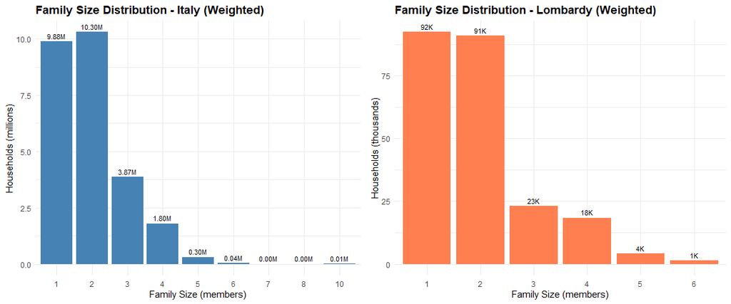

```r
# Italy
p1 <- ggplot(family_size_dist, aes(x = factor(family_size), y = households/1e6)) +
  geom_col(fill = "steelblue") +
  geom_text(aes(label = sprintf("%.2fM", households/1e6)), vjust = -0.5, size = 3) +
  labs(title = "Family Size Distribution - Italy (Weighted)",
       x = "Family Size (members)", y = "Households (millions)") +
  theme_minimal() +
  theme(plot.title = element_text(face = "bold"))

# Lombardy
p2 <- ggplot(lom_dist, aes(x = factor(family_size), y = households/1e3)) +
  geom_col(fill = "coral") +
  geom_text(aes(label = sprintf("%.0fK", households/1e3)), vjust = -0.5, size = 3) +
  labs(title = "Family Size Distribution - Lombardy (Weighted)",
       x = "Family Size (members)", y = "Households (thousands)") +
  theme_minimal() +
  theme(plot.title = element_text(face = "bold"))

gridExtra::grid.arrange(p1, p2, ncol = 2)
```

# 2. North vs South Comparison (Weighted)

```r
# Add macro area
family_size <- family_size %>%
  mutate(macro_area = case_when(
    rip %in% c(1, 2) ~ "North",
    rip == 3 ~ "Center",
    rip %in% c(4, 5) ~ "South"
  ))

# Macro area statistics
macro_stats <- family_size %>%
  filter(!is.na(macro_area)) %>%
  group_by(macro_area) %>%
  summarise(
    avg_size = sum(family_size * weight, na.rm = TRUE) / sum(weight, na.rm = TRUE),
    households = sum(weight, na.rm = TRUE),
    .groups = "drop"
  )

cat("=== Macro Area Comparison ===\n")
```

```
=== Macro Area Comparison ===
```

```r
print(macro_stats)
```

| macro_area | avg_size | households |
| --- | --- | --- |
| Center | 1.910188 | 5322373 |
| North | 1.901266 | 12499979 |
| South | 2.051362 | 8379080 |

```r
# By ripartizione
rip_stats <- family_size %>%
  filter(!is.na(rip)) %>%
  group_by(rip) %>%
  summarise(
    avg_size = sum(family_size * weight, na.rm = TRUE) / sum(weight, na.rm = TRUE),
    households = sum(weight, na.rm = TRUE),
    .groups = "drop"
  ) %>%
  mutate(rip_name = rip_names[as.character(rip)])

cat("\n=== By Ripartizione ===\n")
```

```
=== By Ripartizione ===
```

```r
print(rip_stats)
```

| rip | avg_size | households | rip_name |
| --- | --- | --- | --- |
| 1 | 1.878958 | 7319859 | Nord-Ovest |
| 2 | 1.932790 | 5180120 | Nord-Est |
| 3 | 1.910188 | 5322373 | Centro |
| 4 | 2.087426 | 5577573 | Sud |
| 5 | 1.979561 | 2801507 | Isole |

### Visualization

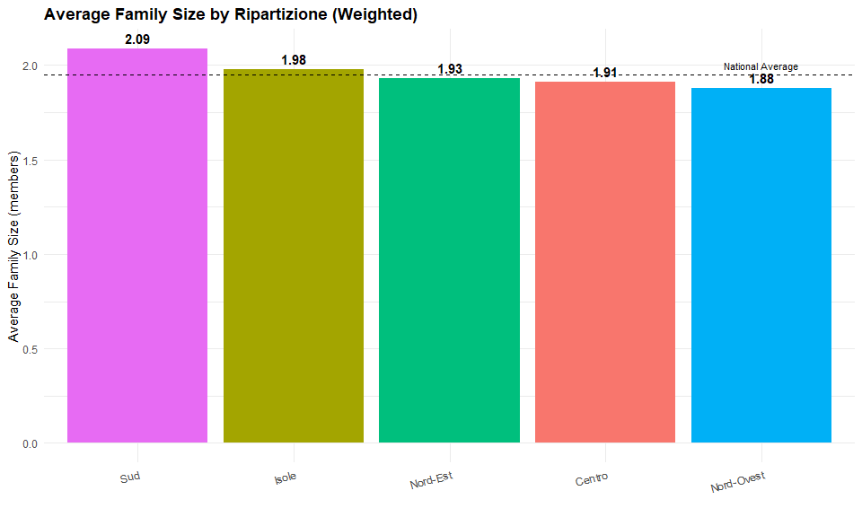

```r
ggplot(rip_stats, aes(x = reorder(rip_name, -avg_size), y = avg_size)) +
  geom_col(aes(fill = rip_name)) +
  geom_hline(yintercept = weighted_avg, linetype = "dashed", color = "black") +
  geom_text(aes(label = sprintf("%.2f", avg_size)), vjust = -0.5, fontface = "bold") +
  annotate("text", x = 5, y = weighted_avg + 0.05, label = "National Average", size = 3) +
  labs(title = "Average Family Size by Ripartizione (Weighted)",
       x = "", y = "Average Family Size (members)") +
  theme_minimal() +
  theme(legend.position = "none",
        plot.title = element_text(face = "bold"),
        axis.text.x = element_text(angle = 15, hjust = 1))
```

# 3. Female Employment Rate (Weighted)

```r
# Working-age females (15-64)
working_age_females <- data_adult %>%
  filter(demo_female == 1, demo_age >= 15, demo_age <= 64)

total_females <- sum(working_age_females$weight, na.rm = TRUE)
employed_females <- sum(working_age_females$weight[working_age_females$demo_empl == 1], na.rm = TRUE)

emp_rate_italy <- employed_females / total_females * 100

cat("=== ITALY ===\n")
```

```
=== ITALY ===
```

```r
cat("Employment Rate:", round(emp_rate_italy, 2), "%\n")
```

```
Employment Rate: 51.14 %
```

```r
cat("Employed females:", format(employed_females, big.mark=","), "\n")
```

```
Employed females: 9,472,721
```

```r
cat("Working-age females:", format(total_females, big.mark=","), "\n")
```

```
Working-age females: 18,523,550
```

```r
# Lombardy
lom_females <- working_age_females %>% filter(reg == 41)
total_lom_fem <- sum(lom_females$weight, na.rm = TRUE)
employed_lom <- sum(lom_females$weight[lom_females$demo_empl == 1], na.rm = TRUE)
emp_rate_lom <- employed_lom / total_lom_fem * 100

cat("\n=== LOMBARDY ===\n")
```

```
=== LOMBARDY ===
```

```r
cat("Employment Rate:", round(emp_rate_lom, 2), "%\n")
```

```
Employment Rate: 66.62 %
```

```r
cat("Employed females:", format(employed_lom, big.mark=","), "\n")
```

```
Employed females: 112,350.4
```

```r
cat("Working-age females:", format(total_lom_fem, big.mark=","), "\n")
```

```
Working-age females: 168,637.8
```

```r
# By Ripartizione
emp_by_rip <- working_age_females %>%
  group_by(rip) %>%
  summarise(
    employed = sum(weight[demo_empl == 1], na.rm = TRUE),
    total = sum(weight, na.rm = TRUE),
    rate = employed / total * 100,
    .groups = "drop"
  ) %>%
  mutate(rip_name = rip_names[as.character(rip)])

cat("\n=== By Ripartizione ===\n")
```

```
=== By Ripartizione ===
```

```r
print(emp_by_rip)
```

| rip | employed | total | rate | rip_name |
| --- | --- | --- | --- | --- |
| 1 | 2962149 | 4898433 | 60.47136 | Nord-Ovest |
| 2 | 2198270 | 3607471 | 60.93661 | Nord-Est |
| 3 | 2078213 | 3674958 | 56.55065 | Centro |
| 4 | 1529347 | 4322525 | 35.38086 | Sud |
| 5 | 704742 | 2020163 | 34.88541 | Isole |

### Visualization

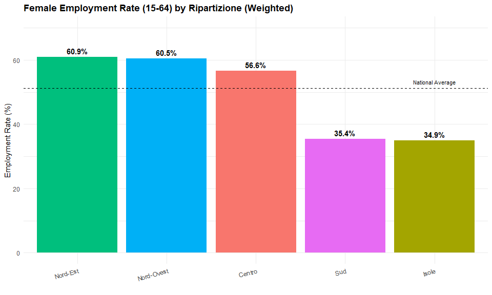

```r
ggplot(emp_by_rip, aes(x = reorder(rip_name, -rate), y = rate)) +
  geom_col(aes(fill = rip_name)) +
  geom_hline(yintercept = emp_rate_italy, linetype = "dashed", color = "black") +
  geom_text(aes(label = sprintf("%.1f%%", rate)), vjust = -0.5, fontface = "bold") +
  annotate("text", x = 5, y = emp_rate_italy + 2, label = "National Average", size = 3) +
  labs(title = "Female Employment Rate (15-64) by Ripartizione (Weighted)",
       x = "", y = "Employment Rate (%)") +
  ylim(0, 70) +
  theme_minimal() +
  theme(legend.position = "none",
        plot.title = element_text(face = "bold"),
        axis.text.x = element_text(angle = 15, hjust = 1))
```

# 4. Distribution of Children per Family (Weighted)

**Note**: Children dataset contains only ages 0-6

```r
# Household info
household_info <- data_adult %>%
  filter(demo_relpar == 1) %>%
  select(hhid, weight, reg, rip)

# Count children per family
children_per_family <- data_children %>%
  group_by(profam) %>%
  summarise(
    n_children = n(),
    coefin = first(coefin),
    .groups = "drop"
  ) %>%
  mutate(weight = coefin / 10000) %>%
  rename(hhid = profam) %>%
  left_join(
    data_adult %>% filter(demo_relpar == 1) %>%
      select(hhid, reg, rip) %>% distinct(),
    by = "hhid"
  )

total_fam_children <- sum(children_per_family$weight, na.rm = TRUE)

cat("=== ITALY - Families with Children (0-6) ===\n")
```

```
=== ITALY - Families with Children (0-6) ===
```

```r
cat("Total families:", format(total_fam_children, big.mark=","), "\n\n")
```

```
Total families: 2,397,253
```

```r
children_dist <- children_per_family %>%
  group_by(n_children) %>%
  summarise(
    families = sum(weight, na.rm = TRUE),
    .groups = "drop"
  ) %>%
  mutate(percentage = families / total_fam_children * 100)

print(children_dist)
```

| n_children | families | percentage |
| --- | --- | --- |
| 1 | 1835294.04 | 76.558199 |
| 2 | 518022.19 | 21.608988 |
| 3 | 40270.70 | 1.679868 |
| 4 | 3666.48 | 0.152945 |

```r
weighted_avg_children <- sum(children_per_family$n_children * children_per_family$weight, na.rm = TRUE) /
                         sum(children_per_family$weight, na.rm = TRUE)
cat("\nWeighted average:", round(weighted_avg_children, 2), "children per family\n")
```

```
Weighted average: 1.25 children per family
```

```r
# Lombardy
lom_children_fam <- children_per_family %>% filter(reg == 41)
total_lom_fam <- sum(lom_children_fam$weight, na.rm = TRUE)

cat("\n=== LOMBARDY - Families with Children (0-6) ===\n")
```

```
=== LOMBARDY - Families with Children (0-6) ===
```

```r
cat("Total families:", format(total_lom_fam, big.mark=","), "\n\n")
```

```
Total families: 27,147.6
```

```r
lom_children_dist <- lom_children_fam %>%
  group_by(n_children) %>%
  summarise(
    families = sum(weight, na.rm = TRUE),
    .groups = "drop"
  ) %>%
  mutate(percentage = families / total_lom_fam * 100)

print(lom_children_dist)
```

| n_children | families | percentage |
| --- | --- | --- |
| 1 | 19065.7076 | 70.229814 |
| 2 | 7235.8101 | 26.653592 |
| 3 | 846.0803 | 3.116594 |

```r
weighted_avg_lom_child <- sum(lom_children_fam$n_children * lom_children_fam$weight, na.rm = TRUE) /
                          sum(lom_children_fam$weight, na.rm = TRUE)
cat("\nWeighted average:", round(weighted_avg_lom_child, 2), "children per family\n")
```

```
Weighted average: 1.33 children per family
```

```r
# All families (including those without children 0-6)
all_families <- household_info %>%
  left_join(children_per_family %>% select(hhid, n_children), by = "hhid") %>%
  mutate(n_children = ifelse(is.na(n_children), 0, n_children))

total_all_fam <- sum(all_families$weight, na.rm = TRUE)

cat("\n=== ALL FAMILIES (including without children 0-6) ===\n")
```

```
=== ALL FAMILIES (including without children 0-6) ===
```

```r
cat("Total families:", format(total_all_fam, big.mark=","), "\n\n")
```

```
Total families: 26,201,432
```

```r
all_children_dist <- all_families %>%
  group_by(n_children) %>%
  summarise(
    families = sum(weight, na.rm = TRUE),
    .groups = "drop"
  ) %>%
  mutate(percentage = families / total_all_fam * 100)

print(head(all_children_dist, 6))
```

| n_children | families | percentage |
| --- | --- | --- |
| 0 | 23804178.58 | 90.85067788 |
| 1 | 1835294.04 | 7.00455624 |
| 2 | 518022.19 | 1.97707588 |
| 3 | 40270.70 | 0.15369657 |
| 4 | 3666.48 | 0.01399343 |

### Visualization

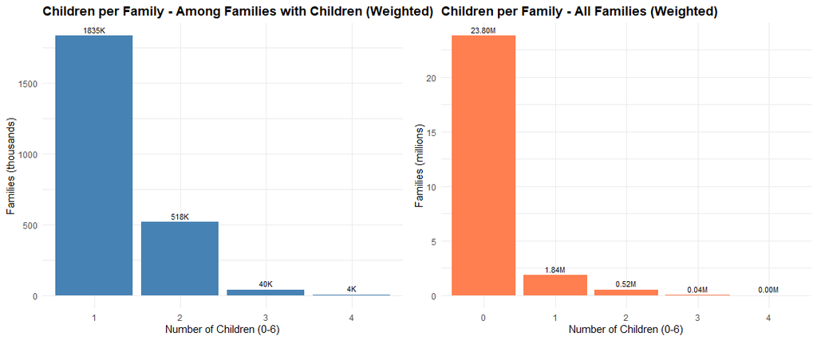

```r
p1 <- ggplot(children_dist, aes(x = factor(n_children), y = families/1e3)) +
  geom_col(fill = "steelblue") +
  geom_text(aes(label = sprintf("%.0fK", families/1e3)), vjust = -0.5, size = 3) +
  labs(title = "Children per Family - Among Families with Children (Weighted)",
       x = "Number of Children (0-6)", y = "Families (thousands)") +
  theme_minimal() +
  theme(plot.title = element_text(face = "bold"))

p2 <- ggplot(head(all_children_dist, 5), aes(x = factor(n_children), y = families/1e6)) +
  geom_col(fill = "coral") +
  geom_text(aes(label = sprintf("%.2fM", families/1e6)), vjust = -0.5, size = 3) +
  labs(title = "Children per Family - All Families (Weighted)",
       x = "Number of Children (0-6)", y = "Families (millions)") +
  theme_minimal() +
  theme(plot.title = element_text(face = "bold"))

gridExtra::grid.arrange(p1, p2, ncol = 2)
```

# 5. Working Mothers (Weighted)

```r
# Employed females aged 15-64
employed_females_data <- data_adult %>%
  filter(demo_female == 1, demo_empl == 1, demo_age >= 15, demo_age <= 64)

total_emp_women <- sum(employed_females_data$weight, na.rm = TRUE)
working_mothers <- sum(employed_females_data$weight[employed_females_data$demo_mother == 1], na.rm = TRUE)

mothers_share_italy <- working_mothers / total_emp_women * 100

cat("=== ITALY ===\n")
```

```
=== ITALY ===
```

```r
cat("Total employed women:", format(total_emp_women, big.mark=","), "\n")
```

```
Total employed women: 9,472,721
```

```r
cat("Working mothers:", format(working_mothers, big.mark=","), "\n")
```

```
Working mothers: 6,337,612
```

```r
cat("Share:", round(mothers_share_italy, 2), "%\n")
```

```
Share: 66.9 %
```

```r
# Lombardy
lom_emp <- employed_females_data %>% filter(reg == 41)
total_lom_emp <- sum(lom_emp$weight, na.rm = TRUE)
lom_mothers <- sum(lom_emp$weight[lom_emp$demo_mother == 1], na.rm = TRUE)
mothers_share_lom <- lom_mothers / total_lom_emp * 100

cat("\n=== LOMBARDY ===\n")
```

```
=== LOMBARDY ===
```

```r
cat("Total employed women:", format(total_lom_emp, big.mark=","), "\n")
```

```
Total employed women: 112,350.4
```

```r
cat("Working mothers:", format(lom_mothers, big.mark=","), "\n")
```

```
Working mothers: 74,324.23
```

```r
cat("Share:", round(mothers_share_lom, 2), "%\n")
```

```
Share: 66.15 %
```

```r
# By Ripartizione
mothers_by_rip <- employed_females_data %>%
  group_by(rip) %>%
  summarise(
    working_mothers = sum(weight[demo_mother == 1], na.rm = TRUE),
    total_employed = sum(weight, na.rm = TRUE),
    share = working_mothers / total_employed * 100,
    .groups = "drop"
  ) %>%
  mutate(rip_name = rip_names[as.character(rip)])

cat("\n=== By Ripartizione ===\n")
```

```
=== By Ripartizione ===
```

```r
print(mothers_by_rip)
```

| rip | working_mothers | total_employed | share | rip_name |
| --- | --- | --- | --- | --- |
| 1 | 1948038.7 | 2962149 | 65.76436 | Nord-Ovest |
| 2 | 1429256.2 | 2198270 | 65.01731 | Nord-Est |
| 3 | 1360425.8 | 2078213 | 65.46134 | Centro |
| 4 | 1127014.9 | 1529347 | 73.69257 | Sud |
| 5 | 472876.1 | 704742 | 67.09918 | Isole |

### Visualization

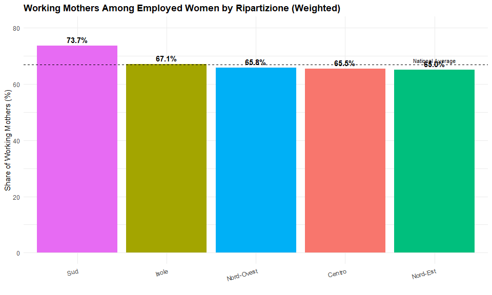

```r
ggplot(mothers_by_rip, aes(x = reorder(rip_name, -share), y = share)) +
  geom_col(aes(fill = rip_name)) +
  geom_hline(yintercept = mothers_share_italy, linetype = "dashed", color = "black") +
  geom_text(aes(label = sprintf("%.1f%%", share)), vjust = -0.5, fontface = "bold") +
  annotate("text", x = 5, y = mothers_share_italy + 1.5, label = "National Average", size = 3) +
  labs(title = "Working Mothers Among Employed Women by Ripartizione (Weighted)",
       x = "", y = "Share of Working Mothers (%)") +
  ylim(0, 80) +
  theme_minimal() +
  theme(legend.position = "none",
        plot.title = element_text(face = "bold"),
        axis.text.x = element_text(angle = 15, hjust = 1))
```

# 6. Pre-School Attendance (Weighted)

**Note**: Children dataset contains ONLY ages 0-6

```r
total_children <- sum(data_children$weight, na.rm = TRUE)

# Merge with household info
children_with_region <- data_children %>%
  left_join(
    data_adult %>% filter(demo_relpar == 1) %>%
      select(hhid, reg, rip) %>% distinct(),
    by = c("profam" = "hhid")
  )

# Formal childcare
attending_formal <- sum(children_with_region$weight[children_with_region$childcare_formal == 1], na.rm = TRUE)
not_attending <- sum(children_with_region$weight[children_with_region$childcare_formal == 0], na.rm = TRUE)

attendance_rate <- attending_formal / total_children * 100

cat("=== ITALY ===\n")
```

```
=== ITALY ===
```

```r
cat("Total children (0-6):", format(total_children, big.mark=","), "\n")
```

```
Total children (0-6): 3,006,816
```

```r
cat("Children in formal childcare:", format(attending_formal, big.mark=","), "\n")
```

```
Children in formal childcare: 1,613,274
```

```r
cat("Children not in formal childcare:", format(not_attending, big.mark=","), "\n")
```

```
Children not in formal childcare: 1,393,543
```

```r
cat("Attendance rate:", round(attendance_rate, 2), "%\n")
```

```
Attendance rate: 53.65 %
```

```r
# By type of care
care_types <- children_with_region %>%
  group_by(care_enrolled) %>%
  summarise(
    children = sum(weight, na.rm = TRUE),
    .groups = "drop"
  ) %>%
  mutate(
    percentage = children / total_children * 100,
    care_type = case_when(
      care_enrolled == 1 ~ "Asilo Nido (Nursery, 0-2)",
      care_enrolled == 14 ~ "Not enrolled",
      care_enrolled == 15 ~ "Scuola Infanzia (Kindergarten, 3-5)",
      care_enrolled == 16 ~ "Scuola Primaria (Primary, 6+)",
      TRUE ~ as.character(care_enrolled)
    )
  )

cat("\n=== By Type of Care ===\n")
```

```
=== By Type of Care ===
```

```r
print(care_types %>% select(care_type, children, percentage))
```

| care_type | children | percentage |
| --- | --- | --- |
| Asilo Nido (Nursery, 0-2) | 949763.4 | 31.58701 |
| Not enrolled | 443779.1 | 14.75910 |
| Scuola Infanzia (Kindergarten, 3-5) | 1169040.7 | 38.87968 |
| Scuola Primaria (Primary, 6+) | 444233.2 | 14.77421 |

```r
# Pre-school specific
preschool_rate <- sum(children_with_region$weight[children_with_region$care_enrolled %in% c(1, 15)], na.rm = TRUE) /
                  total_children * 100
cat("\nPre-school (Asilo Nido + Scuola Infanzia) rate:", round(preschool_rate, 2), "%\n")
```

```
Pre-school (Asilo Nido + Scuola Infanzia) rate: 70.47 %
```

```r
# Lombardy
lom_children <- children_with_region %>% filter(reg == 41)
total_lom_child <- sum(lom_children$weight, na.rm = TRUE)
lom_attending <- sum(lom_children$weight[lom_children$childcare_formal == 1], na.rm = TRUE)
lom_attendance <- lom_attending / total_lom_child * 100

cat("\n=== LOMBARDY ===\n")
```

```
=== LOMBARDY ===
```

```r
cat("Total children (0-6):", format(total_lom_child, big.mark=","), "\n")
```

```
Total children (0-6): 36,075.57
```

```r
cat("Children in formal childcare:", format(lom_attending, big.mark=","), "\n")
```

```
Children in formal childcare: 16,995.04
```

```r
cat("Attendance rate:", round(lom_attendance, 2), "%\n")
```

```
Attendance rate: 47.11 %
```

```r
# By Ripartizione
attendance_by_rip <- children_with_region %>%
  group_by(rip) %>%
  summarise(
    attending = sum(weight[childcare_formal == 1], na.rm = TRUE),
    total = sum(weight, na.rm = TRUE),
    rate = attending / total * 100,
    .groups = "drop"
  ) %>%
  mutate(rip_name = rip_names[as.character(rip)])

cat("\n=== By Ripartizione ===\n")
```

```
=== By Ripartizione ===
```

```r
print(attendance_by_rip)
```

| rip | attending | total | rate | rip_name |
| --- | --- | --- | --- | --- |
| 1 | 454692.9 | 788644.6 | 57.65498 | Nord-Ovest |
| 2 | 315015.6 | 592646.0 | 53.15410 | Nord-Est |
| 3 | 328682.7 | 565675.2 | 58.10448 | Centro |
| 4 | 345314.7 | 737743.8 | 46.80686 | Sud |
| 5 | 169568.0 | 322106.7 | 52.64342 | Isole |

### Visualization

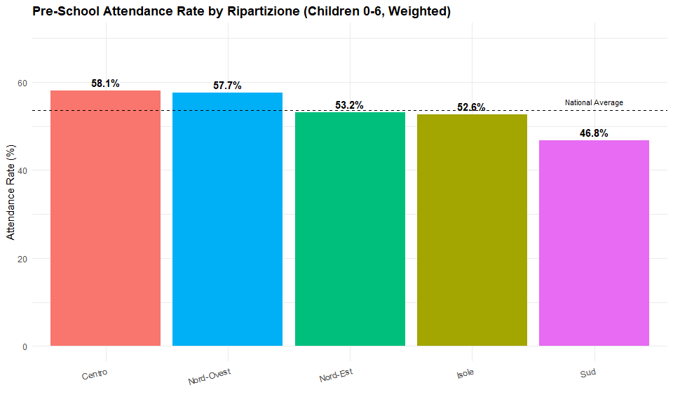

```r
ggplot(attendance_by_rip, aes(x = reorder(rip_name, -rate), y = rate)) +
  geom_col(aes(fill = rip_name)) +
  geom_hline(yintercept = attendance_rate, linetype = "dashed", color = "black") +
  geom_text(aes(label = sprintf("%.1f%%", rate)), vjust = -0.5, fontface = "bold") +
  annotate("text", x = 5, y = attendance_rate + 2, label = "National Average", size = 3) +
  labs(title = "Pre-School Attendance Rate by Ripartizione (Children 0-6, Weighted)",
       x = "", y = "Attendance Rate (%)") +
  ylim(0, 70) +
  theme_minimal() +
  theme(legend.position = "none",
        plot.title = element_text(face = "bold"),
        axis.text.x = element_text(angle = 15, hjust = 1))
```

# Summary Statistics Table

```r
summary_data <- data.frame(
  Indicator = c(
    "Total households (millions)",
    "Average family size (Italy)",
    "Average family size (Lombardy)",
    "Average family size (North)",
    "Average family size (South)",
    "Female employment rate - Italy (%)",
    "Female employment rate - Lombardy (%)",
    "Female employment rate - North (%)",
    "Female employment rate - South (%)",
    "Working mothers share - Italy (%)",
    "Working mothers share - Sud (%)",
    "Pre-school attendance - Italy (%)",
    "Pre-school attendance - Lombardy (%)",
    "Children (0-6) per family (with children)"
  ),
  Value = c(
    round(total_households/1e6, 2),
    round(weighted_avg, 2),
    round(weighted_avg_lom, 2),
    round(macro_stats$avg_size[macro_stats$macro_area == "North"], 2),
    round(macro_stats$avg_size[macro_stats$macro_area == "South"], 2),
    round(emp_rate_italy, 2),
    round(emp_rate_lom, 2),
    round(mean(emp_by_rip$rate[emp_by_rip$rip %in% c(1,2)]), 2),
    round(mean(emp_by_rip$rate[emp_by_rip$rip %in% c(4,5)]), 2),
    round(mothers_share_italy, 2),
    round(mothers_by_rip$share[mothers_by_rip$rip == 4], 2),
    round(attendance_rate, 2),
    round(lom_attendance, 2),
    round(weighted_avg_children, 2)
  )
)

kable(summary_data, caption = "Key Indicators Summary (Weighted)")
```

Key Indicators Summary (Weighted)

| Indicator | Value |
| --- | --- |
| Total households (millions) | 26.20 |
| Average family size (Italy) | 1.95 |
| Average family size (Lombardy) | 1.94 |
| Average family size (North) | 1.90 |
| Average family size (South) | 2.05 |
| Female employment rate - Italy (%) | 51.14 |
| Female employment rate - Lombardy (%) | 66.62 |
| Female employment rate - North (%) | 60.70 |
| Female employment rate - South (%) | 35.13 |
| Working mothers share - Italy (%) | 66.90 |
| Working mothers share - Sud (%) | 73.69 |
| Pre-school attendance - Italy (%) | 53.65 |
| Pre-school attendance - Lombardy (%) | 47.11 |
| Children (0-6) per family (with children) | 1.25 |

*Report generated: 2025-11-20*

*All analyses use proper population weights (coefin/10,000)*

# Points of Discussion

1. The AVQ survey doesn’t have any questions regarding religious stance or conservativeness. I was thinking that maybe this can be proxied with Euroskepticism?
1. There is a question asking about ‘how much do you believe in: European Parliament?’
2. There are also several questions asking the perception of several disorders on their community, such as:
- How safe do you feel walking on the street when it’s dark and you’re alone in the area where you live?
- In the area where you live, how often do you see: people using drugs
- In the area where you live, how often do you see: people dealing drugs
- In the area where you live, how often do you see: prostitutes looking for clients
- In the area where you live, how often do you see: acts of vandalism against public property (broken phone booths, trash bins, etc.)
- In the area where you live, how often do you see: vagrants, people with no fixed address -